# Project 1: Wrangling, Exploration, Visualization

SDS322E

## Data Wrangling, Exploration, Visualization

Kyarah Rogers kr29575

#### Introduction

For this project, I am analyzing information about murders and killings by police in America in 2015.The murder dataset contains information about the locations and number of murders that took place in 2014 and 2015. The police killings dataset contains more detailed statisics about the places where the killings took place. For instance, it includes information about the average income and education levels of households in the area the crimes were committed. I first chose the murders dataset because I’ve been into murder documentaries this Halloween season! I decided to tie in police killings data as it is a specific type of murder that has been receiving a lot of social and political attention. From this project, I am curious to discover what relationships exist, if any, between general murders and murders by police officers in American cities.

```r
library(tidyverse)
data1 <- read_csv("https://raw.githubusercontent.com/fivethirtyeight/data/master/murder_2016/murder_2015_final.csv")
data2 <- read_csv("https://raw.githubusercontent.com/fivethirtyeight/data/master/police-killings/police_killings.csv")
```

#### Tidying: Reshaping

My datasets are tidy already, but I will demonstrate that I can reshape a portion of my data with pivot wider/longer here (e.g., untidy and then retidy).

```r
widerdat2 <- data2 %>% pivot_wider()
widerdat2 %>% pivot_longer(cols = c(1:2))
```

```
## # A tibble: 934 x 33
##    raceethnicity month   day  year streetaddress city  state latitude longitude
##    <chr>         <chr> <dbl> <dbl> <chr>         <chr> <chr>    <dbl>     <dbl>
##  1 Black         Febr…    23  2015 Clearview Ln  Mill… AL        32.5     -86.4
##  2 Black         Febr…    23  2015 Clearview Ln  Mill… AL        32.5     -86.4
##  3 White         April     2  2015 300 block Ir… Pine… LA        31.3     -92.4
##  4 White         April     2  2015 300 block Ir… Pine… LA        31.3     -92.4
##  5 White         March    14  2015 22nd Ave and… Keno… WI        42.6     -87.8
##  6 White         March    14  2015 22nd Ave and… Keno… WI        42.6     -87.8
##  7 Hispanic/Lat… March    11  2015 3000 Seminol… Sout… CA        33.9    -118.
##  8 Hispanic/Lat… March    11  2015 3000 Seminol… Sout… CA        33.9    -118.
##  9 White         March    19  2015 364 Hiwood A… Munr… OH        41.1     -81.4
## 10 White         March    19  2015 364 Hiwood A… Munr… OH        41.1     -81.4
## # … with 924 more rows, and 24 more variables: state_fp <dbl>, county_fp <dbl>,
## #   tract_ce <dbl>, geo_id <dbl>, county_id <dbl>, namelsad <chr>,
## #   lawenforcementagency <chr>, cause <chr>, armed <chr>, pop <dbl>,
## #   share_white <chr>, share_black <chr>, share_hispanic <chr>, p_income <chr>,
## #   h_income <dbl>, county_income <dbl>, comp_income <dbl>,
## #   county_bucket <dbl>, nat_bucket <dbl>, pov <chr>, urate <dbl>,
## #   college <dbl>, name <chr>, value <chr>
```

#### Joining/Merging

```r
joined_project_data <- left_join(data1, data2, by = "city")

data1 %>% summarize(n_distinct(city))
```

```
## # A tibble: 1 x 1
##   `n_distinct(city)`
##                <int>
## 1                 83
```

```r
data2 %>% summarize(n_distinct(city))
```

```
## # A tibble: 1 x 1
##   `n_distinct(city)`
##                <int>
## 1                364
```

```r
joined_project_data %>% summarize(n_distinct(city))
```

```
## # A tibble: 1 x 1
##   `n_distinct(city)`
##                <int>
## 1                 83
```

```r
data1 %>% summarize(n())
```

```
## # A tibble: 1 x 1
##   `n()`
##   <int>
## 1    83
```

```r
data2 %>% summarize(n())
```

```
## # A tibble: 1 x 1
##   `n()`
##   <int>
## 1   467
```

```r
anti_join(data1, data2, by = "city")
```

```
## # A tibble: 30 x 5
##    city                  state          `2014_murders` `2015_murders` change
##    <chr>                 <chr>                   <dbl>          <dbl>  <dbl>
##  1 Philadelphia          Pennsylvania              248            280     32
##  2 St. Louis             Missouri                  159            188     29
##  3 Louisville            Kentucky                   56             81     25
##  4 Charlotte-Mecklenburg North Carolina             47             61     14
##  5 Fort Wayne            Indiana                    12             25     13
##  6 Durham                North Carolina             21             34     13
##  7 Newark                New Jersey                 93            104     11
##  8 Cincinnati            Ohio                       60             66      6
##  9 Tampa                 Florida                    28             34      6
## 10 Colorado Springs      Colorado                   20             25      5
## # … with 20 more rows
```

```r
uniquedat2 <- anti_join(data2, data1, by = "city")
uniquedat2 %>% summarize(n_distinct(city))
```

```
## # A tibble: 1 x 1
##   `n_distinct(city)`
##                <int>
## 1                311
```

```r
joined_project_data %>% summarize(n())
```

```
## # A tibble: 1 x 1
##   `n()`
##   <int>
## 1   158
```

#### Wrangling

```r
samp_table <- joined_project_data %>% filter(city == "Houston") %>%
    select(1, 4, 6:7)
library(knitr)
samp_table %>% kable()
```

| city | 2015_murders | name | age |
| --- | --- | --- | --- |
| Houston | 303 | Alejandro Salazar | Unknown |
| Houston | 303 | Celin Nunez | 24 |
| Houston | 303 | Frank ‘Trey’ Shephard III | 41 |
| Houston | 303 | Hung Trieu | 35 |
| Houston | 303 | Phillip Garcia | 26 |
| Houston | 303 | Victor Reyes | 31 |

```r
joined_project_data %>% filter(city == "Houston") %>% select(1,
    4, 6:7) %>% arrange(desc(age))
```

```
## # A tibble: 6 x 4
##   city    `2015_murders` name                      age
##   <chr>            <dbl> <chr>                     <chr>
## 1 Houston            303 Alejandro Salazar         Unknown
## 2 Houston            303 Frank 'Trey' Shephard III 41
## 3 Houston            303 Hung Trieu                35
## 4 Houston            303 Victor Reyes              31
## 5 Houston            303 Phillip Garcia            26
## 6 Houston            303 Celin Nunez               24
```

```r
joined_project_data %>% filter(state.x == "Texas") %>% group_by(city) %>%
    select(1, 4, 6:9) %>% na.omit
```

```
## # A tibble: 22 x 6
## # Groups:   city [8]
##    city      `2015_murders` name               age    gender raceethnicity
##    <chr>              <dbl> <chr>              <chr>  <chr>  <chr>
##  1 Houston              303 Alejandro Salazar  Unkno… Male   Hispanic/Latino
##  2 Houston              303 Celin Nunez        24     Male   Hispanic/Latino
##  3 Houston              303 Frank 'Trey' Shep… 41     Male   Black
##  4 Houston              303 Hung Trieu         35     Male   Asian/Pacific Isla…
##  5 Houston              303 Phillip Garcia     26     Male   Hispanic/Latino
##  6 Houston              303 Victor Reyes       31     Male   Hispanic/Latino
##  7 Dallas               136 Desmond Luster     45     Male   Black
##  8 Fort Wor…             56 Daniel Brumley     25     Male   Hispanic/Latino
##  9 Fort Wor…             56 Kelvin Goldston    30     Male   Black
## 10 Fort Wor…             56 Reginald McGregor  31     Male   Black
## # … with 12 more rows
```

```r
joined_project_data %>% filter(city == "Houston") %>% mutate(rel_income = h_income/county_income)
```

```
## # A tibble: 6 x 39
##   city  state.x `2014_murders` `2015_murders` change name  age   gender
##   <chr> <chr>            <dbl>          <dbl>  <dbl> <chr> <chr> <chr>
## 1 Hous… Texas              242            303     61 Alej… Unkn… Male
## 2 Hous… Texas              242            303     61 Celi… 24    Male
## 3 Hous… Texas              242            303     61 Fran… 41    Male
## 4 Hous… Texas              242            303     61 Hung… 35    Male
## 5 Hous… Texas              242            303     61 Phil… 26    Male
## 6 Hous… Texas              242            303     61 Vict… 31    Male
## # … with 31 more variables: raceethnicity <chr>, month <chr>, day <dbl>,
## #   year <dbl>, streetaddress <chr>, state.y <chr>, latitude <dbl>,
## #   longitude <dbl>, state_fp <dbl>, county_fp <dbl>, tract_ce <dbl>,
## #   geo_id <dbl>, county_id <dbl>, namelsad <chr>, lawenforcementagency <chr>,
## #   cause <chr>, armed <chr>, pop <dbl>, share_white <chr>, share_black <chr>,
## #   share_hispanic <chr>, p_income <chr>, h_income <dbl>, county_income <dbl>,
## #   comp_income <dbl>, county_bucket <dbl>, nat_bucket <dbl>, pov <chr>,
## #   urate <dbl>, college <dbl>, rel_income <dbl>
```

```r
joined_project_data %>% filter(city == "Houston") %>% mutate(rel_income = h_income/county_income) %>%
    summarize(mean(rel_income))
```

```
## # A tibble: 1 x 1
##   `mean(rel_income)`
##                <dbl>
## 1              0.926
```

```r
joined_project_data %>% filter(state.x == "Texas") %>% group_by(city) %>%
    summarize(mean(h_income)) %>% na.omit
```

```
## # A tibble: 8 x 2
##   city        `mean(h_income)`
##   <chr>                  <dbl>
## 1 Arlington             31875
## 2 Austin                64819.
## 3 Dallas                23931
## 4 El Paso               35792.
## 5 Fort Worth            43214.
## 6 Houston               49185.
## 7 Laredo                42782
## 8 San Antonio           50526.
```

```r
joined_project_data %>% filter(str_detect(city, "^[aeiouAEIOU]")) %>%
    summarize(n_distinct(city))
```

```
## # A tibble: 1 x 1
##   `n_distinct(city)`
##                <int>
## 1                 14
```

```r
joined_project_data %>% group_by(city) %>% na.omit %>% summarize(mean(pop),
    sd(pop), var(pop), quantile(pop), min(pop), max(pop), n_distinct(pop))
```

```
## # A tibble: 265 x 8
## # Groups:   city [53]
##    city  `mean(pop)` `sd(pop)` `var(pop)` `quantile(pop)` `min(pop)` `max(pop)`
##    <chr>       <dbl>     <dbl>      <dbl>           <dbl>      <dbl>      <dbl>
##  1 Albu…       4304.     1272.   1618200.           3404        3404       5203
##  2 Albu…       4304.     1272.   1618200.           3854.       3404       5203
##  3 Albu…       4304.     1272.   1618200.           4304.       3404       5203
##  4 Albu…       4304.     1272.   1618200.           4753.       3404       5203
##  5 Albu…       4304.     1272.   1618200.           5203        3404       5203
##  6 Anah…       7400      3306.  10932488            5062        5062       9738
##  7 Anah…       7400      3306.  10932488            6231        5062       9738
##  8 Anah…       7400      3306.  10932488            7400        5062       9738
##  9 Anah…       7400      3306.  10932488            8569        5062       9738
## 10 Anah…       7400      3306.  10932488            9738        5062       9738
## # … with 255 more rows, and 1 more variable: `n_distinct(pop)` <int>
```

```r
joined_project_data %>% group_by(city, gender) %>% na.omit %>%
    summarize(mean(h_income), sd(h_income), var(h_income), quantile(h_income),
        min(h_income), max(h_income), n_distinct(h_income))
```

```
## # A tibble: 290 x 9
## # Groups:   city, gender [58]
##    city  gender `mean(h_income)` `sd(h_income)` `var(h_income)` `quantile(h_inc…
##    <chr> <chr>             <dbl>          <dbl>           <dbl>            <dbl>
##  1 Albu… Male              47253         10751.       115580808            39651
##  2 Albu… Male              47253         10751.       115580808            43452
##  3 Albu… Male              47253         10751.       115580808            47253
##  4 Albu… Male              47253         10751.       115580808            51054
##  5 Albu… Male              47253         10751.       115580808            54855
##  6 Anah… Female            45353            NA               NA            45353
##  7 Anah… Female            45353            NA               NA            45353
##  8 Anah… Female            45353            NA               NA            45353
##  9 Anah… Female            45353            NA               NA            45353
## 10 Anah… Female            45353            NA               NA            45353
## # … with 280 more rows, and 3 more variables: `min(h_income)` <dbl>,
## #   `max(h_income)` <dbl>, `n_distinct(h_income)` <int>
```

```r
joined_project_data %>% group_by(city) %>% na.omit %>% summarize(mean(county_income),
    sd(county_income), var(county_income), quantile(county_income),
    min(county_income), max(county_income), n_distinct(county_income))
```

```
## # A tibble: 265 x 8
## # Groups:   city [53]
##    city  `mean(county_in… `sd(county_inco… `var(county_inc… `quantile(count…
##    <chr>            <dbl>            <dbl>            <dbl>            <dbl>
##  1 Albu…            48801                0                0            48801
##  2 Albu…            48801                0                0            48801
##  3 Albu…            48801                0                0            48801
##  4 Albu…            48801                0                0            48801
##  5 Albu…            48801                0                0            48801
##  6 Anah…            75422                0                0            75422
##  7 Anah…            75422                0                0            75422
##  8 Anah…            75422                0                0            75422
##  9 Anah…            75422                0                0            75422
## 10 Anah…            75422                0                0            75422
## # … with 255 more rows, and 3 more variables: `min(county_income)` <dbl>,
## #   `max(county_income)` <dbl>, `n_distinct(county_income)` <int>
```

```r
joined_project_data %>% summarize_all(function(x) sum(is.na(x)))
```

```
## # A tibble: 1 x 38
##    city state.x `2014_murders` `2015_murders` change  name   age gender
##   <int>   <int>          <int>          <int>  <int> <int> <int>  <int>
## 1     0       0              0              0      0    30    30     30
## # … with 30 more variables: raceethnicity <int>, month <int>, day <int>,
## #   year <int>, streetaddress <int>, state.y <int>, latitude <int>,
## #   longitude <int>, state_fp <int>, county_fp <int>, tract_ce <int>,
## #   geo_id <int>, county_id <int>, namelsad <int>, lawenforcementagency <int>,
## #   cause <int>, armed <int>, pop <int>, share_white <int>, share_black <int>,
## #   share_hispanic <int>, p_income <int>, h_income <int>, county_income <int>,
## #   comp_income <int>, county_bucket <int>, nat_bucket <int>, pov <int>,
## #   urate <int>, college <int>
```

```r
joined_project_data %>% group_by(gender) %>% summarize(n())
```

```
## # A tibble: 3 x 2
##   gender `n()`
##   <chr>  <int>
## 1 Female     7
## 2 Male     121
## 3 <NA>      30
```

```r
joined_project_data %>% group_by(raceethnicity) %>% summarize(n())
```

```
## # A tibble: 7 x 2
##   raceethnicity          `n()`
##   <chr>                  <int>
## 1 Asian/Pacific Islander     6
## 2 Black                     49
## 3 Hispanic/Latino           33
## 4 Native American            2
## 5 Unknown                    2
## 6 White                     36
## 7 <NA>                      30
```

```r
joined_project_data %>% group_by(month) %>% summarize(n())
```

```
## # A tibble: 6 x 2
##   month    `n()`
##   <chr>    <int>
## 1 April       27
## 2 February    24
## 3 January     29
## 4 March       31
## 5 May         17
## 6 <NA>        30
```

```r
joined_project_data %>% group_by(cause) %>% summarize(n())
```

```
## # A tibble: 5 x 2
##   cause             `n()`
##   <chr>             <int>
## 1 Death in custody      5
## 2 Gunshot             113
## 3 Struck by vehicle     3
## 4 Taser                 7
## 5 <NA>                 30
```

```r
joined_project_data %>% group_by(armed) %>% summarize(n())
```

```
## # A tibble: 8 x 2
##   armed              `n()`
##   <chr>              <int>
## 1 Firearm               57
## 2 Knife                 15
## 3 No                    33
## 4 Non-lethal firearm     2
## 5 Other                  9
## 6 Unknown                2
## 7 Vehicle               10
## 8 <NA>                  30
```

Using filter, I found that there were 6 police killings and 303 murders in Houston in 2015. I changed the format of this table using the kable function. Then, I selected columns for city, 2015 murders, names of police killing victims and their ages to get rid of extraneous details. Arrange allows me to see the list organized by the known victim ages. Next, I was curious to find out how many murders and police killings occurred in different Texas cities. Of all of the Texas cities listed, Houston had both the most police killings and murders in 2015. This makes sense given Houston is the largest of the cities. Next, I used mutate to create a new variable, rel_income, which represents the relative household income for a given county. By diving household income by county income, I get an idea of how wealthy a single household is in its county. The lower the number, the less wealthy. This is just another way of evaluating income in different areas. Looking at household income, I used summarize and mean to see how wealth compared across the Texas cities. I thought it was interesting that Houston was on the wealthier end of the spectrum despite being the city with the most murders, as murders are typically correlated with lower income areas. Other factors could explain this, such as a murder percentage for each city based on total population; for instance, Houston had the most murders and police killings, but that may not be significant relative to its population. Finally, I used str_detect and found that 14 of the city names in the joined dataset start with a vowel. One interesting finding from my summary statistics was that San Jose was the city with the greatest average county income, but Washington had the greatest household income. Also, an overwhelming majority of police killing victims were men and committed by gunshot, which was not surprising to find given the reported incidents we see in the news.

#### Visualizing

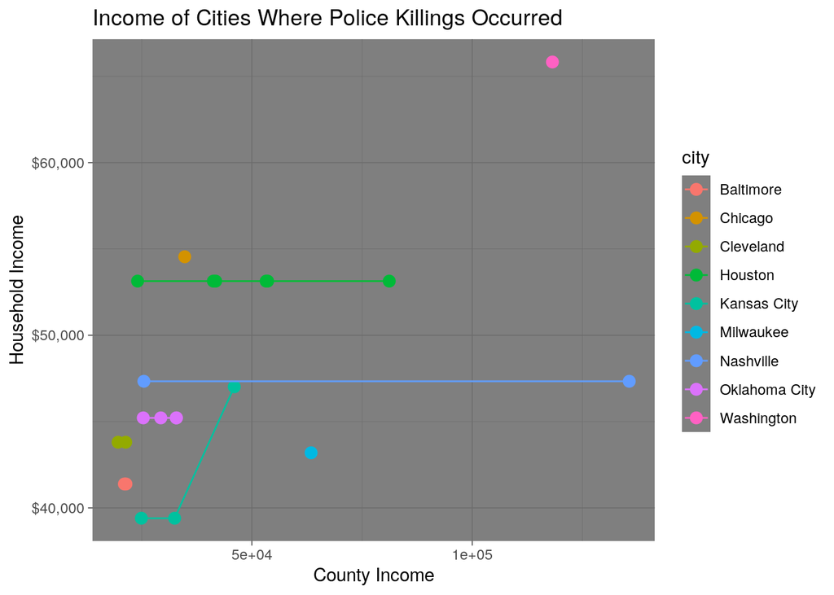

```r
joined_project_data %>% slice(1:25) %>% na.omit %>% ggplot(aes(x = h_income,
    y = county_income, color = city)) + geom_point(size = 3) +
    geom_line(aes(group = city)) + ggtitle("Income of Cities Where Police Killings Occurred") +
    xlab("County Income") + ylab("Household Income") + theme_dark() +
    scale_y_continuous(labels = scales::dollar)
```

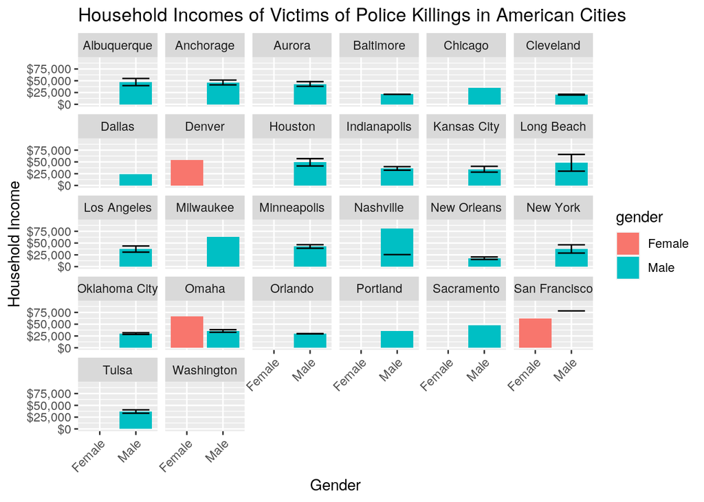

```r
joined_project_data %>% slice(1:75) %>% group_by(city, gender) %>%
    na.omit %>% summarize(meanh = (mean(h_income)), sdh = (sd(h_income)),
    n = n(), seh = sdh/sqrt(n)) %>% ggplot(aes(gender, meanh,
    fill = gender)) + geom_bar(stat = "summary") + geom_errorbar(aes(y = meanh,
    ymin = meanh - seh, ymax = meanh + seh), width = 0.75) +
    facet_wrap(~city) + ggtitle("Household Incomes of Victims of Police Killings in American Cities") +
    xlab("Gender") + ylab("Household Income") + theme(axis.text.x = element_text(angle = 45,
    hjust = 1)) + scale_y_continuous(lim = c(0, 95000), labels = scales::dollar)
```

The first detail to note here is the overwhelming majority of male victims of police killing incidents compared to women. Many cities have no reported cases of women being killed by police. Many of the places where these incidents took place had household incomes below $50,000.

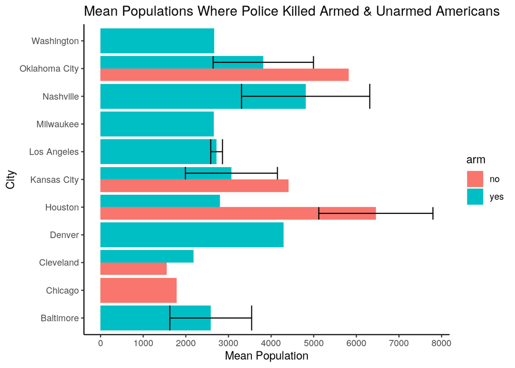

```r
joined_project_data %>% select(city, armed, pop) %>% na.omit %>%
    slice(1:25) %>% mutate(arm = ifelse(armed == "No", "no",
    "yes")) %>% group_by(city, arm) %>% summarize(mean = mean(pop),
    se = sd(pop)/sqrt(n())) %>% ggplot(aes(city, mean, fill = arm)) +
    geom_bar(stat = "identity", position = "dodge") + geom_errorbar(aes(ymin = mean -
    se, ymax = mean + se), position = "dodge") + coord_flip() +
    ggtitle("Mean Populations Where Police Killed Armed & Unarmed Americans") +
    xlab("City") + ylab("Mean Population") + theme_classic() +
    scale_y_continuous(breaks = seq(0, 60000, 1000))
```

Again, no obvious trends here; however, there are some interesting things to note. For one, it appears that most incidents took place when victims were armed. This would support the idea that an officer likely killed the victim in self defense. The populations in the city areas where a majority of these cases took place averaged between 2000 and 3000. Also, in areas where there were unarmed as well as armed victims, populations were usually larger where unarmed victims were killed. Like the other graphs, trends could be more evident with more cities and incidents included. The number of cities and incidents are kept smaller here for the sake of simplicity.